# Final Paper

STOR 320.01 Group 7

December 09, 2018

# INTRODUCTION

Our group decided to delve into the movie industry with a data set from TMDb (The Movie Database). We started by condensing the data to contain 1434 complete observations as well as the corresponding variables we were interested in exploring. Once we had a clean data set, we decided to investigate the following question: What are the best covariates to predict revenue? These covariates consisted of release date, budget, runtime, and popularity. For revenue, we began by performing simple linear regressions for revenue, against release day, release month, and release year. We noticed that only the model between release month against revenue had some sort of pattern among all the observations. While the most popular months seemed intuitive, the specific days within a month to best release a movie didn’t seem as obvious. This led our group to investigate the days in the month that are the best to release a movie for the different months of the year. For both the highest and lowest grossing months, the specific days to release a movie within these months is useful knowledge for production companies.

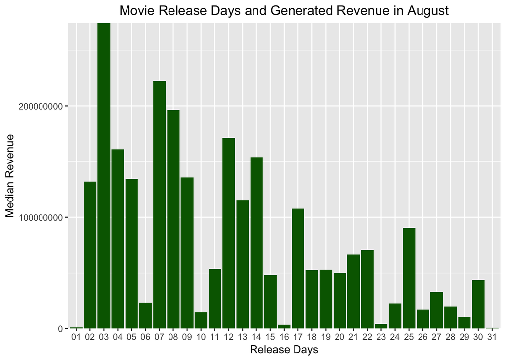

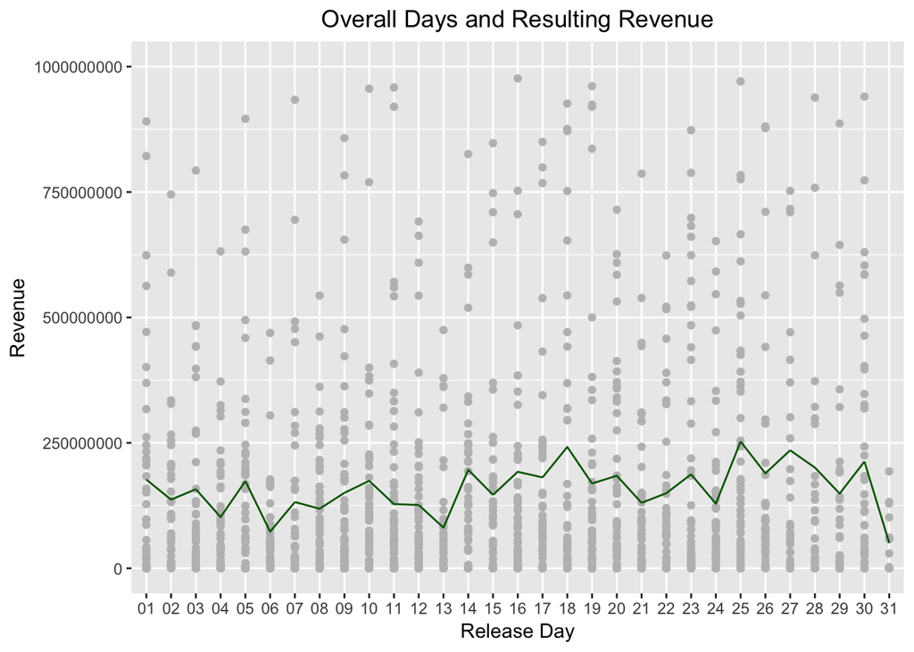

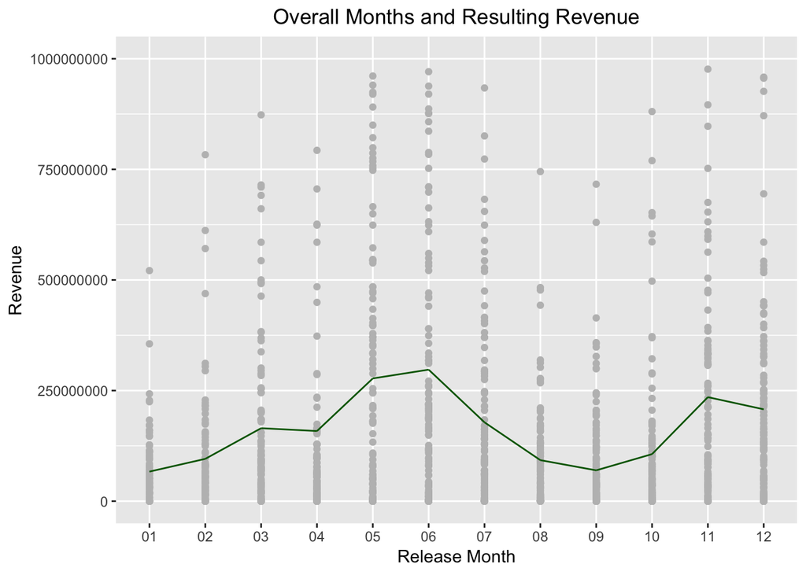

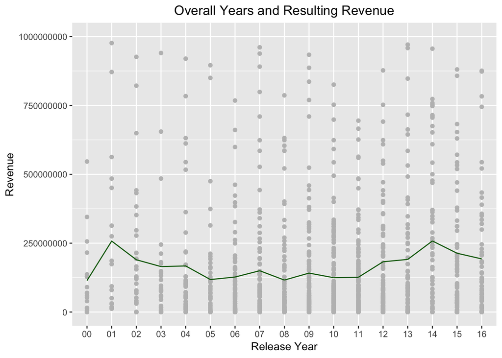

After understanding what factors affect revenue, we decided to examine the other response variable production companies care about: popularity. In other words, do certain genres have better popularity scores based on runtime and/or other predictors? Since budget had the most influence on revenue, we decided to see how runtime affected popularity. First of all, we observed that the average runtime is around 100-120 minutes and were curious to see how shorter or longer movies performed. After realizing the fluctuation within runtime was primarily due to production company and genre, we decided to consider the ideal runtimes for each individual genre. By understanding this response, production companies can make more insightful decisions about the runtime of particular movies. Equally important, by understanding ideal runtimes, directors can make more efficient decisions on their budgeting for a movie.

# DATA

The dataset pulled from Kaggle originated from TMDb (The Movie Database), where metadata from IMDB is scraped by an international community since 2008 (https://www.themoviedb.org/about). The data was spread across two tables: movies and credits. However, we decided to only use the movies table. This table contained 4803 observations of movies, along with 20 columns regarding information of a movie’s title, tagline, revenue, etc. In this project we will only be focusing on the variables listed below. Here is a description and summary statistics for each:

- Genre - the genres/categories of the movie (Action, Comedy, Fantasy, etc.)
- Original Language - the original language in which the movie was made
- Production Companies - the names of production companies producing the movie
- Tagline - the tagline of the movie
- Budget - the amount spent making the movie (US Dollars)
- Popularity - a metric based on various factors, such as number of votes for the day, number of views for the day, number of users who marked it as a “favorite” for the day, number of users who added it to their “watchlist” for the day, release date, number of total votes, previous day’s score to determine a movie’s popularity
- Release Date - the date the movie was released
- Revenue - the worldwide amount earned from the movie (US Dollars)
- Runtime - the duration of the movie in minutes

### Data Frame Summary

**fullmovies**  
**N:** 1434

| No | Variable | Stats / Values | Freqs (% of Valid) | Text Graph | Valid | Missing |
| --- | --- | --- | --- | --- | --- | --- |
| 1 | budget [integer] | mean (sd) : 47634718.98 (54069620.53) min < med < max : 0 < 30000000 < 380000000 IQR (CV) : 56000000 (1.14) | 239 distinct values |  | 1434 (100%) | 0 (0%) |
| 2 | id [integer] | mean (sd) : 63908.01 (88917.74) min < med < max : 11 < 24556 < 394047 IQR (CV) : 66666.25 (1.39) | 1434 distinct values |  | 1434 (100%) | 0 (0%) |
| 3 | original_language [character] | 1. en 2. es 3. fr 4. de 5. ja 6. zh 7. ko 8. id 9. pt 10. af [ 10 others ] | 1383 (96.4%) 9 ( 0.6%) 9 ( 0.6%) 5 ( 0.3%) 5 ( 0.3%) 5 ( 0.3%) 3 ( 0.2%) 2 ( 0.1%) 2 ( 0.1%) 1 ( 0.1%) 10 ( 0.7%) | IIIIIIIIIIIIIIII | 1434 (100%) | 0 (0%) |
| 4 | popularity [numeric] | mean (sd) : 36.96 (48.75) min < med < max : 0.05 < 26.09 < 875.58 IQR (CV) : 32.93 (1.32) | 1434 distinct values |  | 1434 (100%) | 0 (0%) |
| 5 | release_date [Date] | min : 1937-12-20 med : 2009-11-09 max : 2016-09-09 range : 78y 8m 20d | 1181 distinct val. |  | 1434 (100%) | 0 (0%) |
| 6 | revenue [numeric] | mean (sd) : 160750012.62 (243793781.71) min < med < max : 0 < 68491826.5 < 2787965087 IQR (CV) : 183782874 (1.52) | 1269 distinct values |  | 1434 (100%) | 0 (0%) |
| 7 | runtime [integer] | mean (sd) : 109.06 (19.3) min < med < max : 0 < 106 < 201 IQR (CV) : 25 (0.18) | 106 distinct values |  | 1434 (100%) | 0 (0%) |
| 8 | tagline [character] | 1. Based on the incredible t 2. One ordinary couple. One 3. One way in. No way out. 4. The only way out is down. 5. Who is John Galt? 6. -If anyone asks. 7. . . . pick a side. 8. (n. One who has retur… | 2 ( 0.1%) 2 ( 0.1%) 2 ( 0.1%) 2 ( 0.1%) 2 ( 0.1%) 1 ( 0.1%) 1 ( 0.1%) 1 ( 0.1%) 1 ( 0.1%) 1 ( 0.1%) 1419 (99.0%) | IIIIIIIIIIIIIIII | 1434 (100%) | 0 (0%) |
| 9 | title [character] | 1. (500) Days of Summer 2. [REC] 3. [REC]² 4. #Horror 5. 10 Cloverfield Lane 6. 12 Rounds 7. 13 Hours: The Secret Sold 8. 1408 9. 17 Again 10. 1911 [ 1424 others ] | 1 ( 0.1%) 1 ( 0.1%) 1 ( 0.1%) 1 ( 0.1%) 1 ( 0.1%) 1 ( 0.1%) 1 ( 0.1%) 1 ( 0.1%) 1 ( 0.1%) 1 ( 0.1%) 1424 (99.3%) | IIIIIIIIIIIIIIII | 1434 (100%) | 0 (0%) |
| 10 | Action [numeric] | mean (sd) : 0.28 (0.45) min < med < max : 0 < 0 < 1 IQR (CV) : 1 (1.59) | 0 : 1027 (71.6%) 1 : 407 (28.4%) | IIIIIIIIIIIIIIII IIIIII | 1434 (100%) | 0 (0%) |
| 11 | Comedy [numeric] | mean (sd) : 0.34 (0.47) min < med < max : 0 < 0 < 1 IQR (CV) : 1 (1.4) | 0 : 949 (66.2%) 1 : 485 (33.8%) | IIIIIIIIIIIIIIII IIIIIIII | 1434 (100%) | 0 (0%) |
| 12 | Drama [numeric] | mean (sd) : 0.42 (0.49) min < med < max : 0 < 0 < 1 IQR (CV) : 1 (1.18) | 0 : 836 (58.3%) 1 : 598 (41.7%) | IIIIIIIIIIIIIIII IIIIIIIIIII | 1434 (100%) | 0 (0%) |
| 13 | Thriller [numeric] | mean (sd) : 0.28 (0.45) min < med < max : 0 < 0 < 1 IQR (CV) : 1 (1.6) | 0 : 1031 (71.9%) 1 : 403 (28.1%) | IIIIIIIIIIIIIIII IIIIII | 1434 (100%) | 0 (0%) |
| 14 | Fantasy [numeric] | mean (sd) : 0.12 (0.33) min < med < max : 0 < 0 < 1 IQR (CV) : 0 (2.7) | 0 : 1261 (87.9%) 1 : 173 (12.1%) | IIIIIIIIIIIIIIII II | 1434 (100%) | 0 (0%) |
| 15 | Walt Disney Pictures [numeric] | mean (sd) : 0.04 (0.2) min < med < max : 0 < 0 < 1 IQR (CV) : 0 (4.83) | 0 : 1375 (95.9%) 1 : 59 ( 4.1%) | IIIIIIIIIIIIIIII | 1434 (100%) | 0 (0%) |
| 16 | Universal Pictures [numeric] | mean (sd) : 0.09 (0.28) min < med < max : 0 < 0 < 1 IQR (CV) : 0 (3.24) | 0 : 1309 (91.3%) 1 : 125 ( 8.7%) | IIIIIIIIIIIIIIII I | 1434 (100%) | 0 (0%) |
| 17 | Warner Bros. [numeric] | mean (sd) : 0.09 (0.28) min < med < max : 0 < 0 < 1 IQR (CV) : 0 (3.25) | 0 : 1310 (91.3%) 1 : 124 ( 8.6%) | IIIIIIIIIIIIIIII I | 1434 (100%) | 0 (0%) |
| 18 | Columbia Pictures [numeric] | mean (sd) : 0.06 (0.24) min < med < max : 0 < 0 < 1 IQR (CV) : 0 (3.96) | 0 : 1348 (94.0%) 1 : 86 ( 6.0%) | IIIIIIIIIIIIIIII I | 1434 (100%) | 0 (0%) |
| 19 | Paramount Pictures [numeric] | mean (sd) : 0.05 (0.23) min < med < max : 0 < 0 < 1 IQR (CV) : 0 (4.17) | 0 : 1356 (94.6%) 1 : 78 ( 5.4%) | IIIIIIIIIIIIIIII | 1434 (100%) | 0 (0%) |
| 20 | Relativity Media [numeric] | mean (sd) : 0.05 (0.22) min < med < max : 0 < 0 < 1 IQR (CV) : 0 (4.42) | 0 : 1364 (95.1%) 1 : 70 ( 4.9%) | IIIIIIIIIIIIIIII | 1434 (100%) | 0 (0%) |
| 21 | Twentieth Century Fox Film Corporation [numeric] | mean (sd) : 0.04 (0.2) min < med < max : 0 < 0 < 1 IQR (CV) : 0 (4.92) | 0 : 1377 (96.0%) 1 : 57 ( 4.0%) | IIIIIIIIIIIIIIII | 1434 (100%) | 0 (0%) |
| 22 | New Line Cinema [numeric] | mean (sd) : 0.04 (0.19) min < med < max : 0 < 0 < 1 IQR (CV) : 0 (4.96) | 0 : 1378 (96.1%) 1 : 56 ( 3.9%) | IIIIIIIIIIIIIIII | 1434 (100%) | 0 (0%) |

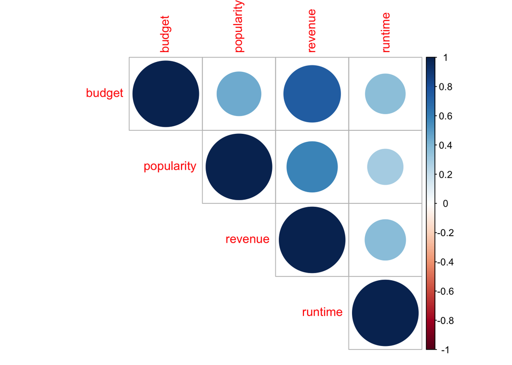

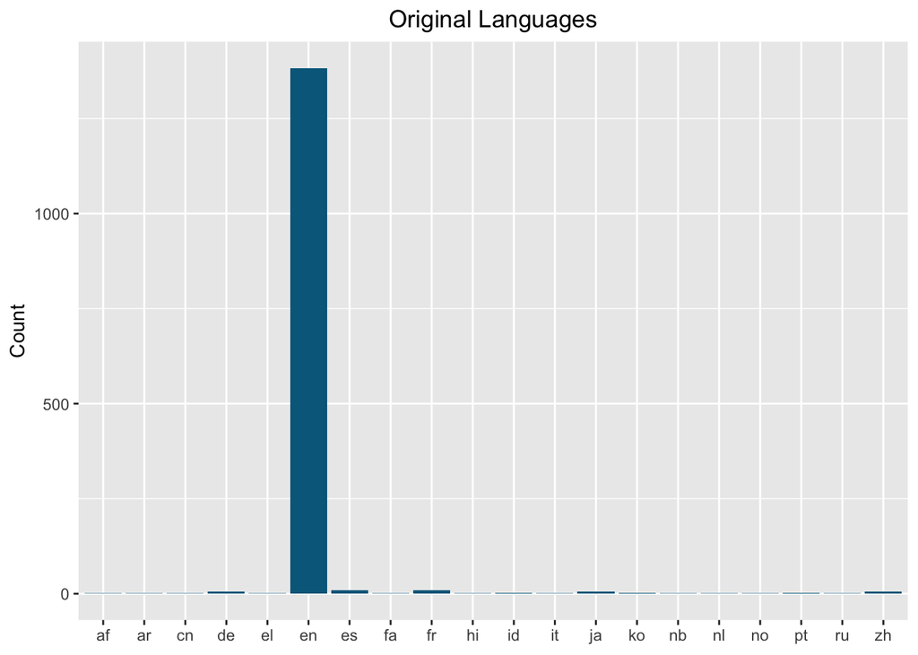

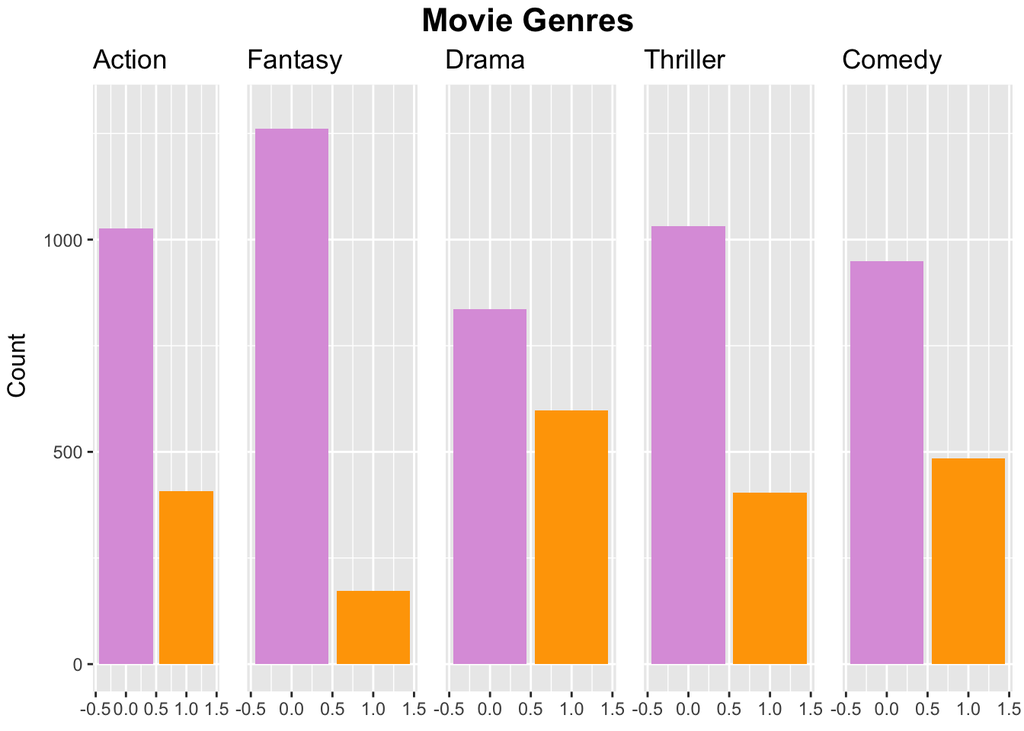

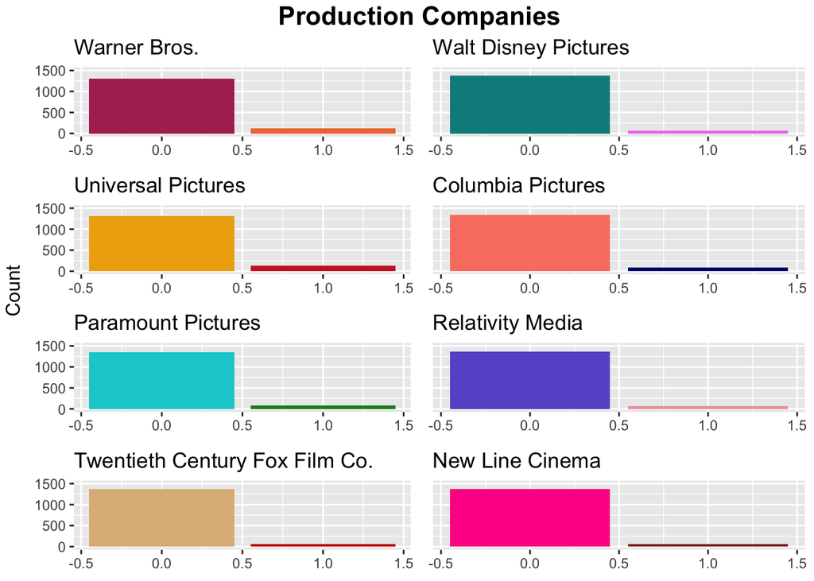

# RESULTS

Based on our exploratory data analysis, we decided to answer the following question: Do certain genres have better popularity scores based on runtime and/or other predictors? We split the data into five different genres: Action, Comedy, Drama, Thriller, and Fantasy. The Fantasy genre had 173 observations while the rest of the genres had at least 400 observations. Leave-one-out cross-validation (LOOCV) and polynomial regression were conducted for each of the five genres with runtime as the predictor variable and popularity as the response variable. The order of the regression model was based on the lowest square root of the mean squared error (RMSE). Action and Fantasy fit a linear model the best. Comedy fit a degree 3 polynomial model the best, but we would recommend a linear model because the RMSE for it was only 0.1 worse than the more complex degree 3 polynomial model. Thriller fit a degree 3 polynomial model the best, and Drama fit a degree 4 polynomial model the best. Fantasy had the lowest RMSE out of all the genres, but it also had the least observations to be considered. Other covariates, like budget, were explored to possibly be included in the model along with runtime. However, the correlation of runtime with these covariates was low, and their respective p-values showed insignificance. Thus the RMSE was not significantly reduced when adding other available predictors to the previous models.

| Degree | Root MSE |
| --- | --- |
| 1 | 53.98687 |
| 3 | 54.08163 |
| 5 | 54.11404 |
| 2 | 54.62031 |
| 4 | 55.02409 |
| 6 | 60.34908 |
| 7 | 62.11058 |
| 8 | 317.48125 |
| 9 | 2381.06243 |
| 10 | 2470.35097 |

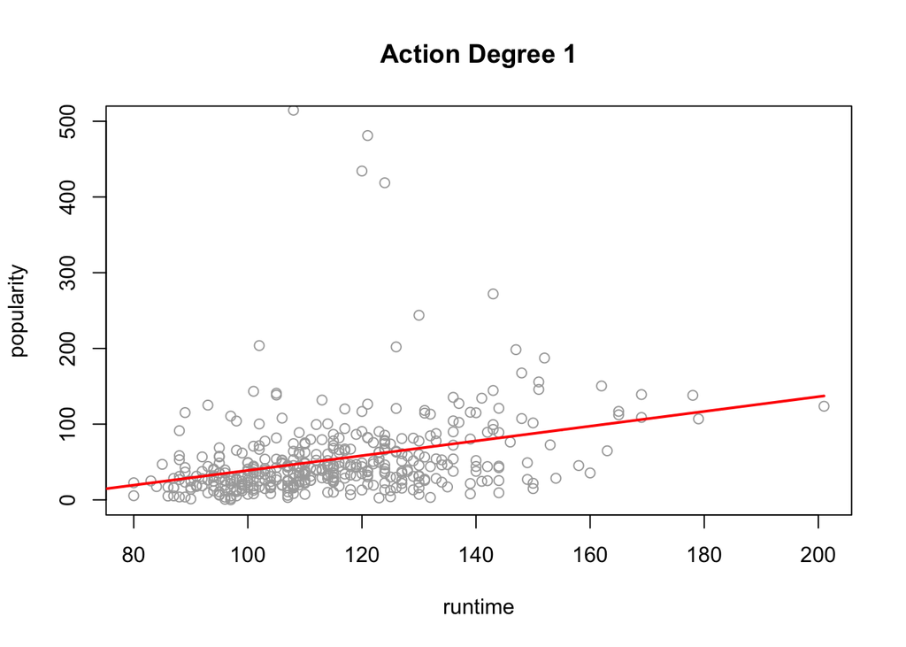

| Degree | Root MSE |
| --- | --- |
| 3 | 50.78347 |
| 1 | 50.89259 |
| 2 | 51.00601 |
| 4 | 51.42501 |
| 5 | 51.66672 |
| 6 | 53.38445 |
| 8 | 75.27742 |
| 7 | 102.31629 |
| 9 | 1209.75747 |
| 10 | 27429.92822 |

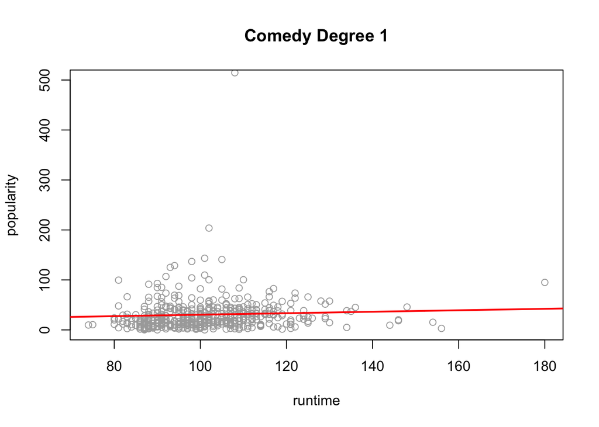

| Degree | Root MSE |
| --- | --- |
| 4 | 38.41697 |
| 5 | 38.71784 |
| 1 | 38.82172 |
| 2 | 38.85453 |
| 3 | 38.91181 |
| 8 | 39.15337 |
| 6 | 39.34123 |
| 9 | 39.86923 |
| 7 | 39.95630 |
| 10 | 174.20568 |

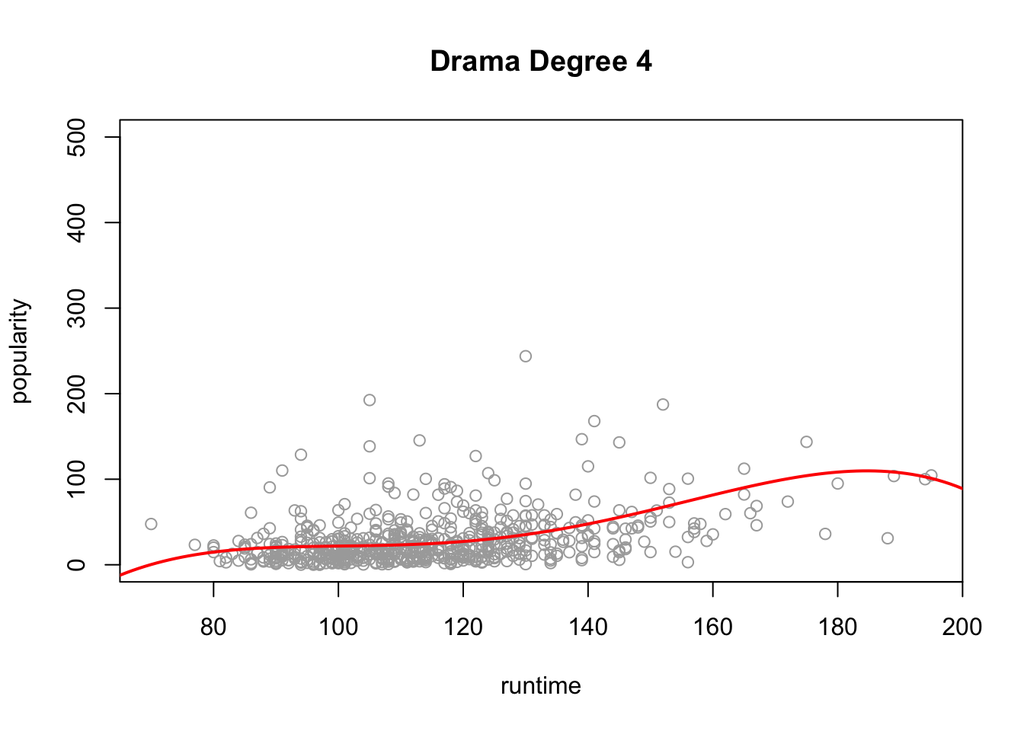

| Degree | Root MSE |
| --- | --- |
| 3 | 39.31577 |
| 2 | 39.32360 |
| 1 | 39.52607 |
| 4 | 40.16171 |
| 7 | 42.32591 |
| 5 | 47.43861 |
| 6 | 104.14107 |
| 8 | 1077.23635 |
| 9 | 4308.12035 |
| 10 | 5096.38272 |

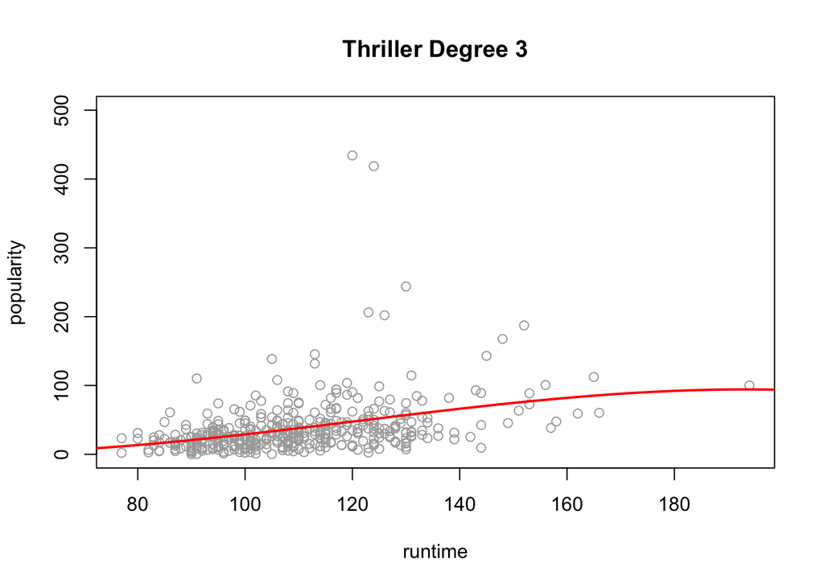

| Degree | Root MSE |
| --- | --- |
| 1 | 33.22931 |
| 2 | 33.34015 |
| 3 | 33.56095 |
| 4 | 34.38936 |
| 5 | 34.71431 |
| 7 | 36.11841 |
| 6 | 36.31957 |
| 8 | 42.79398 |
| 9 | 94.20729 |
| 10 | 118.40995 |

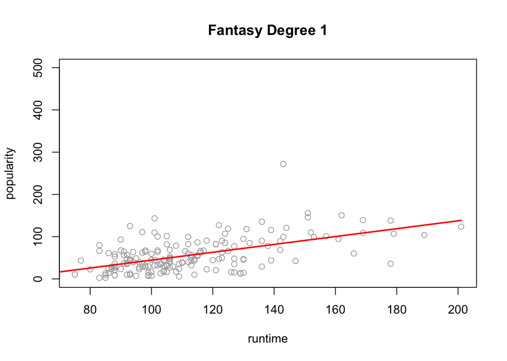

To summarize, Action movies with longer runtimes tended to have higher popularity scores. Comedy movies held the shortest runtimes in general, and longer runtimes did not translate into higher popularity. Drama movies with longer runtimes tended to have slightly higher popularity, but one should be cautious to make the movie too long. A similar case can be observed with Thriller movies, although they have shorter runtimes compared to Drama movies. Fantasy movies with longer runtimes clearly had higher popularity, but as stated before there were less observations than the other genres.

Additionally, we decided to answer the following question: What are the best covariates to predict revenue? We began by investigating the relationships of revenue with release date, budget, runtime, and popularity. A simple linear regression was conducted to predict revenue based on release day, release month, and release year. However, these variables were not the best predictors of revenue as seen in the figures. We conducted polynomial regression with budget as the predictor and revenue as the response. A degree 3 polynomial model yielded the best results. We followed this with looking at popularity as the predictor and revenue as the response. Degree 5 and degree 1 polynomial models were both investigated. Degree 5 generated the best results as compared to degree 4, degree 8, and degree 1. Note that in the modeling we only included movies with popularities between 0 and 150 so as not to a) overfit the data and b) make significant test prediction errors in the future.

| Degree | Root MSE |
| --- | --- |
| 3 | 163153336 |
| 2 | 164337264 |
| 1 | 164659037 |
| 4 | 165739981 |
| 6 | 170930366 |
| 5 | 175371765 |
| 7 | 1082292108 |
| 8 | 3030153489 |
| 9 | 6818475972 |
| 10 | 26127973677 |

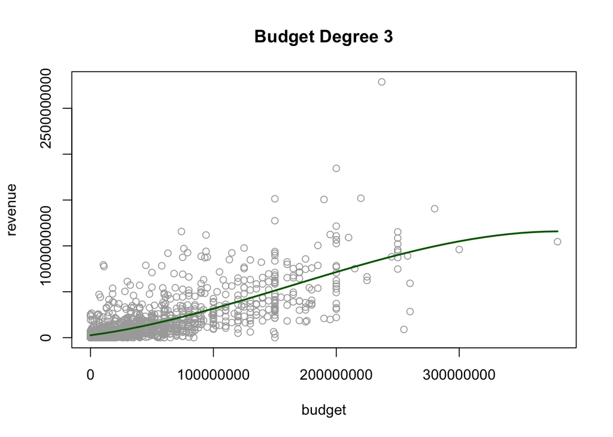

| Degree | Root MSE |
| --- | --- |
| 5 | 158005918 |
| 4 | 158136566 |
| 8 | 158564097 |
| 1 | 158947646 |
| 2 | 159165815 |
| 6 | 159510350 |
| 3 | 159698788 |
| 7 | 160103941 |
| 10 | 161505039 |
| 9 | 163572306 |

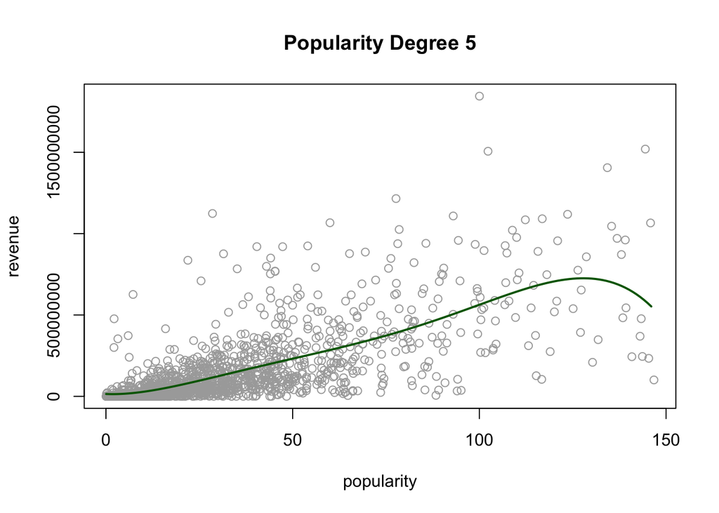

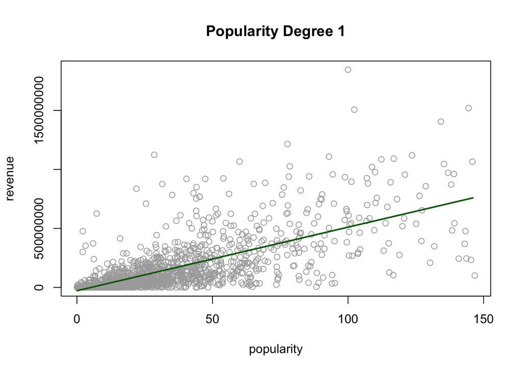

| term | p.value |
| --- | --- |
| (Intercept) | 0.0143086 |
| budget | 0.0002302 |
| popularity | 0.4084168 |
| runtime | 0.0037919 |
| budget:popularity | 0.0351166 |
| budget:runtime | 0.0000000 |
| popularity:runtime | 0.2078126 |
| budget:popularity:runtime | 0.0108957 |

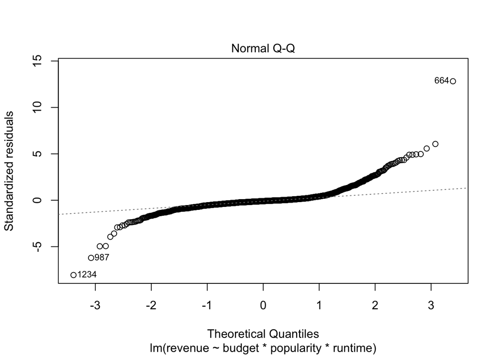

| Interactions | Root MSE |
| --- | --- |
| budget and popularity | 151745356 |
| budget and runtime | 158846317 |
| budget and popularity and runtime | 160224250 |
| popularity and runtime | 215069849 |

| Degree | Root MSE |
| --- | --- |
| 4 | 145178980 |
| 2 | 147200591 |
| 1 | 149503103 |
| 3 | 153724415 |
| 5 | 382422253 |
| 7 | 12624945662 |
| 6 | 28986099382 |
| 8 | 253399000571 |
| 10 | 472607172253 |
| 9 | 685204759658 |

# CONCLUSION

After noting there were some extremely successful (measured in revenue) movies that had a much lower budget than its peers, we were most interested in exploring revenue out of all the variables our group had access to in our data set. We began by experimenting with different regression models to understand how the pairing of different predictors affected movie sales. We initially expected budget and the production company to be the best predictors of revenue, but after the analysis we found that budget and popularity were the best predictors for revenue. While popularity is harder to anticipate, there are some initial insights into whether a movie will have a positive response by the public. For budget, we think production companies can use this data to better understand the relationship with revenue and how other variables interact with expenses. A larger budget alone is not necessarily needed for a successful movie. During our analysis, we also found that release date, release month, and release year were not the best predictors for revenue; production companies can keep this mind whilst producing movies. To continue our analysis, we think one can break up movies into genres to see if certain months are more receptive to different genres in terms of revenue.

The film industry has had various changes in the last decade in the way consumers interact with movies. By understanding the sales of a movie, those involved in media production could also have a better understanding of the business model of a film. Writers and directors are usually not involved with a movie after the production phase but still have equity in the performance of their movies. Moving forward, directors can have a better understanding of anticipated revenue of a film and make more thoughtful decisions with budget during the production phase of a company. On the other hand, by understanding how variables interact with each other, production companies can intentionally make decisions to maximize revenue by optimizing runtime, genre, budget, and the anticipated popularity score. Finally, we’re aware that some of the variables that can be used to better understand sales are missing from the data set. Realistically, the money spent is not as much an indicator of the success of a movie as is *how* that money is spent. We didn’t know what amount of the budget was being used for advertising compared to actual movie production, which can give us a false idea of the relationship with budget and revenue. The advertising channels and amount of marketing done (and timing) would be ideal variables to consider in order to continue looking into maximizing revenue.

Lastly, our group came up with a couple ideas about future directions we could take with movie data. The first is utilizing a specific NLP method known as sentiment analysis. In this data set, we only have the popularity scores. But if we also had user reviews, then we could apply sentiment analysis to determine which reviews were positive, negative, or neutral. This information can then be used to better determine popularity, which then acts as a covariate for predicting revenue. The second is utilizing multiple predictors to classify a movie into a certain genre or genres. Two popular methods that came to mind were support vector machines and LDA/QDA. Netflix AI (if it doesn’t already) will eventually have the capability to aggregate user reviews and other data to recommend specific movies to the user that are both a) the most popular and b) the exact requested genre or genres.